# Why Kpop Groups Have So Many Members?

As I pointed it out in [part.1 of Kpop Data Analysis](https://charliezcr.github.io/kda.html). On average, Kpop groups have 5.5 members. 5-member group is the most common form. Usually, a Kpop group consists of a main vocalist, a main rapper, a main dancer, a visual (the gorgeous member that usually do acting and modeling for solo activities). This is all it needs to form a small Kpop group, like BLACKPINK and aespa. For larger groups, there are positions like lead vocalists, sub-vocalists, lead dancers, lead rappers. But why can some Kpop groups become so big? The largest Kpop group, NCT, has 23 members. I did an exploratory data analysis of Kpop group sizes by timeline.

```
Debut
1995    2.0
1996    5.0
1997    4.7
1998    6.0
1999    3.5
2001    4.0
2003    5.0
2004    4.0
2005    6.0
2006    4.5
2007    5.4
2008    4.8
2009    5.0
2010    5.5
2011    5.3
2012    5.7
2013    6.2
2014    5.3
2015    6.2
2016    6.1
2017    6.7
2018    6.6
2019    5.6
2020    5.9
2021    7.0
Name: Orig. Memb., dtype: float64
```

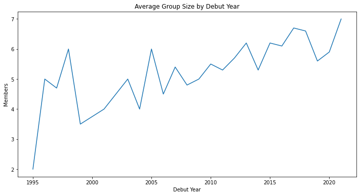

```python
import pandas as pd
import numpy as np
import matplotlib.pyplot as plt
plt.rcParams['figure.figsize'] = [12, 6]

boys = pd.read_csv('kpop_idols_boy_groups.csv')
girls = pd.read_csv('kpop_idols_girl_groups.csv')
all_groups = pd.concat([boys, girls])
all_groups.Debut = pd.to_datetime(all_groups.Debut)
all_groups.Debut = [debut.year for debut in all_groups.Debut]
all_groups.Company.replace(to_replace=[''], value=np.nan, inplace=True)
all_groups.Company = all_groups.Company.str.split(", ")
average = round(all_groups.groupby("Debut")['Orig. Memb.'].mean(),1)
average.plot(title="Average Group Size by Debut Year", ylabel="Members", xlabel="Debut Year")
average
```

## Timeline of Average Kpop Group size

As we can see by the statistics above, the average Kpop group size generally increases year by year. Because there are too few Kpop groups debuting before 2000, the sample size is not big enough. Therefore, we can just look at the data after 2000. From 2001 to 2021, the average group size rose from 4 to 7. Especially, there is a small peak at 2005. This was because **Super Junior**, the first large-size (male) Kpop group debuted.

If we consider a Kpop group with 2-4 people as a small-size group, 5-7 people as a medium size group, then a group with over 7 people is a large size group. Super Junior, However, debuted with a whopping 12 members, and had 13 members at their peak. Also, Super Junior's Agency, **SM Entertainment** debuted the the first large-size female Kpop group as well in 2007 -- **Girls' Generation (SNSD)** with 9 members. This is also the reason why there is another small peak at 2007 in the chart above.

It was a bold and innovative trial for SM Entertainment to produce large-size Kpop groups at first. It might seem to be excessive to have so many people on stage. But eventually, Super Junior and Girls' Generation both became the most successful Kpop groups because their activities are also arranged in a different way from smaller groups. Here are the advantages of big groups:

1. Big groups have lots of members. Each members can attract fans individually. These fans will follow their favorite member to notice the group activity and became attracted to the group too. Therefore, big groups generally draw more attention than small groups.
2. Big groups have different types of members. They can break into many fields for their solo activities and attract fans from different areas. For example, some members are singers, some are variety show hosts, some are actors, and some are good at reality shows.
3. Big groups can break into sub-units and try different styles to attract fans. For example, Super Junior made the first sub-unit in the history of Kpop - K.R.Y. This sub-unit consists of 3 main vocalists of Super Junior. Super Junior's But K.R.Y.'s performance is more like a band. Besides K.R.Y., Super Junior also has numerous other sub-units. For the next generation big groups, the sub-unit activities became more and more creative. For example, when EXO debuted, they did not debut together but debuted as 2 sub-units -- EXO-K and EXO-M. EXO-K performed Korean version of their songs and promoted in Korea, while EXO-M performed Mandarin version of their songs and promoted in China. Later, the 2 sub-units merged together as the whole group when they became famous both in Korea and China.
4. Big groups suffer less when they lost a member. It is quite a loss for a 5-member group to lose one member, but not that harmful for a 13 member group to lose a member. For example, Super Junior still has 9 members today and their group activities are still going on after 15 years. Even though there are constantly members going to military service and others quitting the group, the large groups and still maintain the group activity while some members are absent.
5. Big groups are famous for their group dance (Kalgunmu). It is spectacular to watch many people dancing with synchronized movement. Big groups' group dance be can designed to have sophisticated formation changes, which small groups cannot have.

Because of the early big groups' success, Kpop companies produced more and more big groups later on. By far, there are 59 large-size groups, consisting of 16.21% of all Kpop groups.

```python
big = all_groups[all_groups["Orig. Memb."]>7]
big.shape[0]
```

```
59
```

```python
round(big.shape[0]/all_groups.shape[0],4)
```

```
0.1621
```

```python
big = big.sort_values(by=['Debut'])
big.groupby('Debut')['Name'].count()
```

```
Debut
2005     1
2007     1
2010     2
2011     1
2012     2
2013     2
2014     1
2015     4
2016     7
2017    12
2018    14
2019     3
2020     8
2021     1
Name: Name, dtype: int64
```

## Timeline of Large-size Kpop Groups

Here is the timeline of big groups only. We can see that big groups started within the 2nd Generation Kpop groups (2004 - 2011). This was the time that Kpop groups quickly developed and created the first batch of successful big groups like Super Junior and Girls' Generation I mentioned above. But there was only 1 or 2 big groups debuting from 2005 to 2014. After 2015, among the 3rd Generation Kpop groups, the number of big groups debuting each year drastically increased and reached the maximum of 14 groups in 2018. A feature of this era is the craze of survival reality shows, where the trainees compete with each other to get the chance of debuting in a big group according to the audience's votes. In 2015, JYP Entertainment brought out its 16 female trainees for its survival reality show and debuted the 9-member group **TWICE**. Later, TWICE became the most successful Kpop group at the time. From 2016 to 2019, Mnet made 4 seasons of the survival reality show **Produce 101**. The show gathers 101 trainees each year from different Kpop companies. For Season 3, Produce 48, the show even gathered Jpop idols from AKB48 series groups. Produce 101 series produced 3 11-member groups **I.O.I, Wanna One, X1** and a 12-member **IZ*ONE**. Because of the popularity of the shows themselves and because the members were selected by the audiences. These big groups from survival reality shows also became extremely successful.

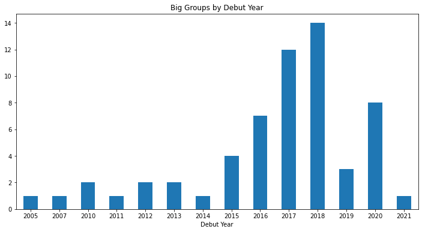

```python
big.groupby('Debut')['Name'].count().plot.bar(title="Big Groups by Debut Year", xlabel="Debut Year",rot=0)
```

However, after 2018, the number of big groups debuting decreased significantly. I could not find an evidence-backed explanation for that. If you have any opinions, please let me know. I can only speculate that maybe big groups reached a market saturation then. Although big groups have great advantages that make them successful, there are also disadvantages:

1. It is expensive for the company to support a big group. It is reported that the cost of training a member of Girls' Generation reached a million USD. Kpop agencies also need to pay more cost after they debut. More members means more dorm rooms, more transportation fees, more make-up and clothing, and more living expenses. A solo artist can also be as successful as the most sucessful big groups, but solo artists are not that costy to their agencies.
2. Members are underpaid as they need to split up the paymemt. For the same reason above, each member can only get a little share of the group's income.
3. Members cannot get enough attention for their individual charisma. Performing in a big groups requires sacrifice of individuality. Each member can only get a few lines in a song. Some popular members might outshine other members in the same group. However, everyone will go for solo activities eventually that requires attentions on individuals.
4. Even though it is easier to maintain a big group when some members leave. The loss of members can still have a tremendous negative impact on the group

Because of these disadvantages, big groups are not garuanteed to become successful. It is also difficult for successful big groups to maintain their popularity. That might be the reason why we have enough big groups today.